# Zenbait tresna teknologiko 📹

Juan Abasolo

# IKTak aukera

## Hizkuntza idatziaz

[video not shown]

## Ariketa bat HHko gelan: *Zer du gogoko umeak?*

[+](http://munitibarkoeskolahlhi.blogspot.com/search?updated-max=2016-05-04T15:20:00%2B02:00&max-results=7) - [++](http://munitibarkoeskolahlhi.blogspot.com/search?updated-max=2016-04-13T15:48:00%2B02:00&max-results=7&start=7&by-date=false)

### KJO9I874ºGHU

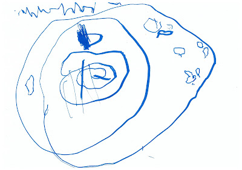

3 urte eta 5 hile

### OCIEA UEX OAEA

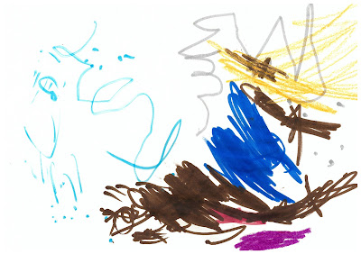

4 urte eta hilabete

### LORAK BIE

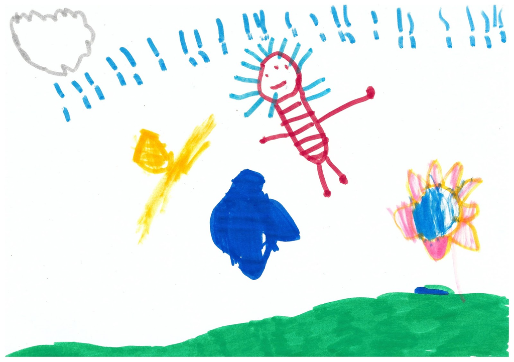

4 urte eta 5 hile

### DANSA EGTA

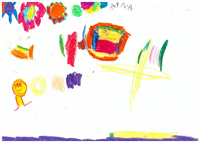

4 urte eta 7 hile

### KOPAKO COKOA

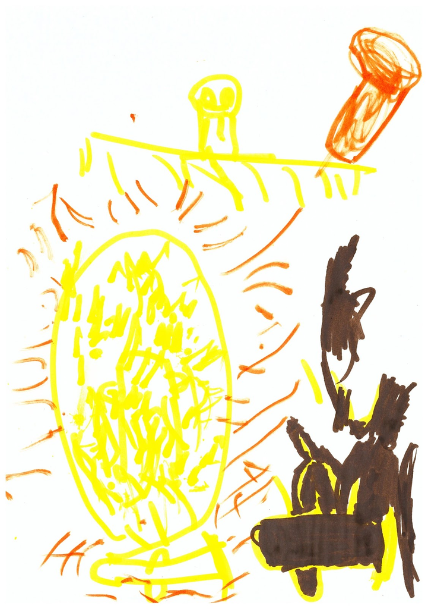

4 urte eta 9 hile

### MUEAI JOLSTA

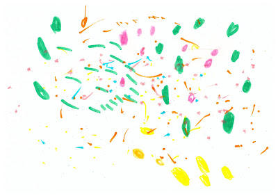

4 urte eta 9 hile

### PAIOJ OLASTEA

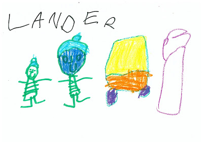

5 urte eta 4 hile

### ESKUPPILOTAN GOLSTEA

[figure not shown]

6 urte eta hile bi

## Atzo

[Lurralde ezberdinak](https://munitibarkoeskola456.blogspot.com/)

# Bestelako erreminta batzuk

Hipertesuak eta hiper-estekak

Ideiak mapeatzeko softwarea

Idazketan aztertzeko tresnak eta IDAT

**Ariketa (1/3)**

framapad.org helbidean sartu eta sortu dokumentu bat hor honako idatzia egiteko:

Berbazko diskurtso irakurria idatzi behar duzu, lanean hasi berria zaren ikastetxeak IKTen erabilera beste era batera bideratzearen onurez konbentzitzeko.

**Nork**: Irakasle hasi berria  
**Norentzat**: Irakasle zahar eta ohituraz erratuak  
**Zertarako**: Claustroan irakurtzeko  
**Helburua**: Aldaketaren beharraz konbentzitzea

Hori idazten ez zenuke pasatu beharko 20 minutu baino gutxiago ezta 30 baino askoz gehiago ere.

## IDAT

Aurkezpen sui generisa ⏯️

## Idazketaren modeloa

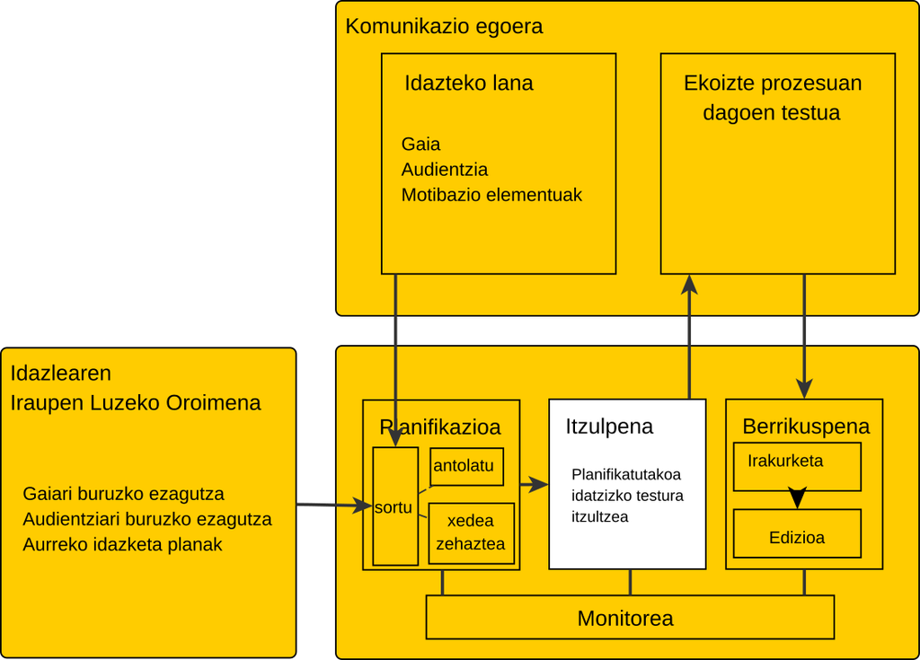

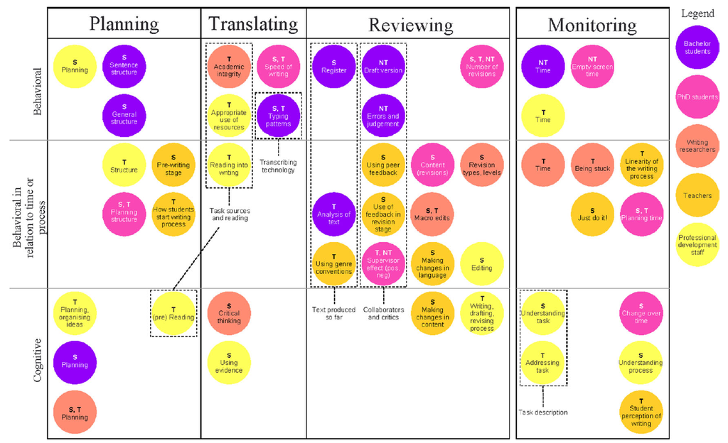

**Ariketa 2/3**

Taldekideon artean aztertu binaka edo hirunaka zuon idatziak IDATapp erabilita

labur.eus/HDIBidatapp

**Ariketa 3/3**

Taldekideon artean eztabaidatu zuok baliabideon erabilgarritasuna gelan.

Zerk lagunduko lioke gelako irakasleari ikasleen idazketa prozesuan aurrera egiten

# Taldean idaztea

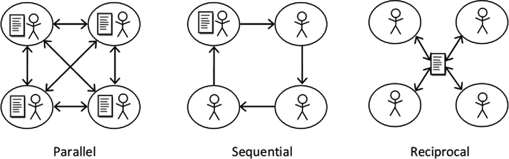

## Egiletzarako estrategiak

Posner & Baecker (1992)

Idazle bakarreko estrategia

Idazle banatuen estrategia

Eskribaren estrategia

Taldekako idazketarako estrategia

Aholku estrategia

## Egiletza

- Idazle nagusia
- Egiletza banatua
- Berrikuspen kooperatiboa
- Baterako idazketaren estrategia

**Aztertu taldeko idatzia**

Deskribatu eta azaldu taldeko jardunaren nondik norakoa, ebidentzietan oinarriturik (taldeka?)

Azaldu horretan ikusten duzuena (banaka)

[figure not shown]

IKTen erabilera, tresnak eta aukerak